# Tips on getting component data from NASIS into R

2016-01-21  
D.E. Beaudette, J.M. Skovlin, S. Roecker

> This tutorial is based on essential background material described in the [soilDB](https://r-forge.r-project.org/scm/viewvc.php/*checkout*/docs/soilDB/soilDB-Intro.html?root=aqp) and related [NASIS ODBC connection](https://r-forge.r-project.org/scm/viewvc.php/*checkout*/docs/soilDB/setup_local_nasis.html?root=aqp) tutorials. If you have not reviewed those tutorials, please do so before proceeding.

> The functions and documentation described in this tutorial are still a work in progress.

## Introduction

The `soilDB` package contains a number of **convenience functions** (usually having a prefix of "fetch") for extracting data from commonly used databases, performing basic quality control checks, and returning the result as a [SoilProfileCollection](https://r-forge.r-project.org/scm/viewvc.php/*checkout*/docs/aqp/aqp-intro.html?root=aqp) object. In order to simplify the process of stitching-together the many linked (and sometimes nested) tables associated with data in NASIS, convenience functions (e.g. `fetchNASIS()` or `fetchNASIS_component_data()`) must make a number of assumptions about the data. This document describes how those assumptions can be adjusted and how they may affect subsequent data analysis.

## Pedon Data

Please see the [related tutorial on loading NASIS pedon data into R](https://r-forge.r-project.org/scm/viewvc.php/*checkout*/docs/soilDB/fetchNASIS-mini-tutorial.html?root=aqp).

## Component Data

Load up your local database and selected set with some components. NASIS queries should "target" the tables:

- Component
- Data Mapunit
- Correlation
- Mapunit
- Legend Mapunit
- Legend
- Area

The most commonly used data from the data map unit, component, component horizon tables can be quickly loaded using the `fetchNASIS_component_data()` function.

```r
# load required libraries
library(soilDB)
library(plyr)

# get component + component horizon data as a SoilProfileCollection, using defaults
nc <- fetchNASIS_component_data()
```

The result is a [SoilProfileCollection](https://r-forge.r-project.org/scm/viewvc.php/*checkout*/docs/aqp/aqp-intro.html?root=aqp) object and can be subset or visualized as such. Lets try extracting just the components with names that match the pattern "Amador".

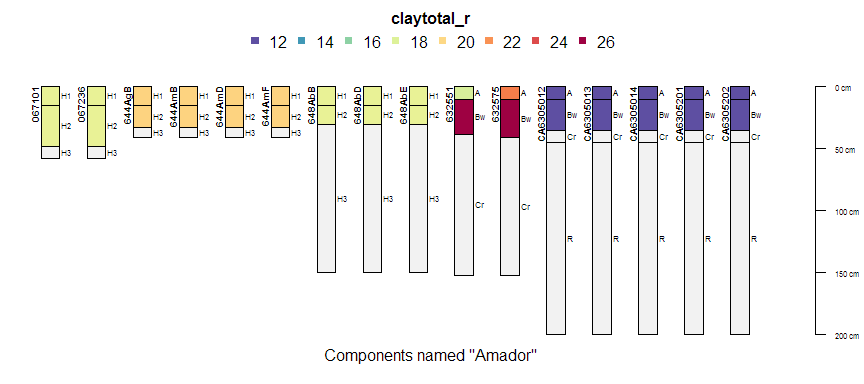

```r
# filter out just those components named "Amador"
idx <- grep('Amador', nc$compname, ignore.case = TRUE)
nc.sub <- nc[idx, ]

# plot
par(mar=c(2,0,3,0))
plot(nc.sub, color='claytotal_r', label='dmudesc')
title(sub='Components named "Amador"', line=0)
```

There appear to be many duplicate components. This isn't surprising as a single component template is commonly shared among many map units. Lets filter out a unique subset of components based on horizon depth, horizon designation, and clay content.

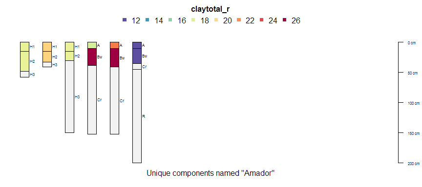

```r
# generate an index to unique components and subset
idx <- unique(nc.sub, vars=c('hzdept_r', 'hzdepb_r', 'claytotal_r', 'hzname'))
nc.sub.unique <- nc.sub[idx, ]

# plot the subset
par(mar=c(2,0,3,0))
plot(nc.sub.unique, color='claytotal_r', print.id=FALSE, n=length(nc.sub))
title(sub='Unique components named "Amador"', line=0)
```

## Accessing Additional Types of "Component" Data

### Linked Pedons

Sometimes it is convenient to know which pedons are linked to components. The following function returns a `data.frame` (table) of data containing component record IDs, pedon record IDs, and pedon IDs. This can be used to link the results of `fetchNASIS_component_data()` to the results of `fetchNASIS()` (pedon data). Lets assemble a list of all pedons linked to a component named "Amador", using the subset from above.

```r
# get the full set of linked pedon data from the selected set
nc.linked.pedons <- get_copedon_from_NASIS_db()
# check format
head(nc.linked.pedons)
```

| coiid | peiid | pedon_id | representative |
| --- | --- | --- | --- |
| 1353433 | 64475 | 301S | 0 |
| 1153779 | 64477 | 641I | 1 |
| 1153793 | 64477 | 641I | 1 |
| 1153792 | 64477 | 641I | 1 |
| 1153791 | 64477 | 641I | 1 |
| 1153790 | 64477 | 641I | 1 |

```r
# list just those pedons that are linked to our subset of components
# note that we are using the component record ID (coiid) to connect the two data sources
idx <- which(nc.linked.pedons$coiid %in% site(nc.sub)$coiid)
nc.linked.pedons[idx, ]
```

|  | coiid | peiid | pedon_id | representative |
| --- | --- | --- | --- | --- |
| 2172 | 1297566 | 158468 | S04CA099-003 | 1 |
| 2173 | 1297559 | 158468 | S04CA099-003 | 1 |
| 2712 | 2331927 | 542170 | 2012CA6303043 | 1 |
| 2716 | 2073965 | 620526 | 2012CA6304005 | 1 |

### Map Unit, Correlation, Legend, Area Tables

The NASIS data elements that exist at levels higher than the data map unit table must be loaded with a different function because there isn't always a 1:1 mapping between data map unit objects and map unit / legend objects.

```r
nc.correlation <- get_component_correlation_data_from_NASIS_db()
head(nc.correlation, 1)
```

|  | muiid | musym | nationalmusym | muname | mukind | mustatus | muacres | farmlndcl | repdmu | dmuiid | areasymbol | areaname | survey_status | cordate |
| --- | --- | --- | --- | --- | --- | --- | --- | --- | --- | --- | --- | --- | --- | --- |
| 325 | 1406634 | 121su | 1j6q9 | Columbia fine sandy loam, 0 to 2 percent slopes, frequently flooded | consociation | correlated | 164 | Not prime farmland | 1 | 288917 | CA612 | Butte Area, California, Parts of Butte and Plumas Counties | Published | 2005-04-01 |

Lets tabulate the occurrence of components named "Amador" by soil survey area and component kind, using data loaded in the above examples.

```r
# combine basic site data + correlation / legend data
# note that there is a 1:many relationship
nc.combined <- join(site(nc.sub), nc.correlation, by='dmuiid')

# cross-tabulate
xtabs( ~ areasymbol + compkind, data=nc.combined)
```

| areasymbol/compkind | series | taxadjunct |
| --- | --- | --- |
| CA067 | 2 | 0 |
| CA628 | 1 | 0 |
| CA630 | 5 | 0 |
| CA632 | 0 | 2 |
| CA644 | 4 | 0 |
| CA648 | 3 | 0 |

### Component Ecological Site Data

Details pending.

```r
nc.esd <- get_component_esd_data_from_NASIS_db
```

Additional tutorials are available at the [AQP project website](http://aqp.r-forge.r-project.org/).

## Example Applications

These examples are still a work in progress. Detailed descriptions pending...

### Check for DMU Linked to Multiple Map Units

There are some cases where a single DMU may be linked to multiple map units (*such as...*).

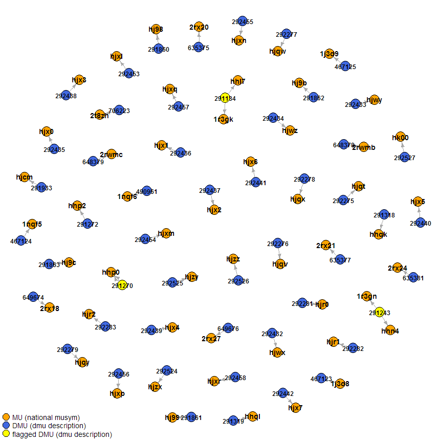

```r
library(igraph)

# re-load relevant data from NASIS:
# just MU/DMU objects with components named "Amador"
nc <- get_component_data_from_NASIS_db()
idx <- grep('Amador', nc$compname, ignore.case = TRUE)
nc.sub <- nc[idx, ]
nc.correlation <- get_component_correlation_data_from_NASIS_db()
nc.combined <- join(nc.sub, nc.correlation, by='dmuiid')

# extract edges of graph linking DMU --> MU
e <- na.omit(nc.combined[, c('dmuiid', 'nationalmusym')])

# create vertex attributes
v <- rbind(cbind(name=e[, 1], color='RoyalBlue', label.cex=0.75), cbind(name=e[, 2], color='Orange', label.cex=0.85))
v <- as.data.frame(v, stringsAsFactors = FALSE)
v$label.font <- 2
v$label.cex <- as.numeric(v$label.cex)

# optionally flag DMUs that connect to multiple MU
if(exists('multiple.mu.per.dmu', envir=soilDB.env)) {
  dupe.dmu <- get('multiple.mu.per.dmu', envir=soilDB.env)
  v$color[which(v$name %in% dupe.dmu)] <- 'Yellow'
}

# create graph
g <- graph.data.frame(e, directed=TRUE, vertices = unique(v))
V(g)$size <- 5

# check
par(mar=c(0,0,0,0))
set.seed(10101)
plot(g, vertex.label.color='black', vertex.label.family='sans',  edge.arrow.size=0.5)
legend('bottomleft', legend = c('MU (national musym)', 'DMU (dmu description)', 'flagged DMU (dmu description)'), pt.bg=c('Orange', 'RoyalBlue', 'Yellow'), pch=21, pt.cex=2, cex=0.85, bty='n')
```

### Rank Component Records Based on Horizon Data Population

Rank data map units that contain a major component named "Amador" based on the degree to which component horizon data has been populated.

```r
library(lattice)
# re-load relevant data from NASIS:
# get the component data
nc <- get_component_data_from_NASIS_db()
# subset columns to those we are using
nc <- nc[, c('dmuiid', 'dmudesc', 'coiid', 'compname', 'comppct_r', 'majcompflag')]
# just MU/DMU objects with components named "Amador"
idx <- grep('Amador', nc$compname, ignore.case = TRUE)
nc <- nc[idx, ]
# look only at major components for now
nc <- nc[which(nc$majcompflag == 1), ]

# get component horizon data
nc.hz <- fetchNASIS_component_data()
# subset the unique set of component IDs that have horizon data
nc.hz.coiids <- site(nc.hz)$coiid

# make a new column and fill with '0' when no horizon data present, '1' when horizon data present
nc$hz.data.present <- 0
nc$hz.data.present[which(nc$coiid %in% nc.hz.coiids)] <- 1

# get correlation data and join to component data
nc.correlation <- get_component_correlation_data_from_NASIS_db()
nc.combined <- join(nc, nc.correlation, by='dmuiid', type='inner')

# tabulate components w/o hz data, w/ hz data, and total components
addmargins(table(nc.combined$hz.data.present))
```

| 0 | 1 | Sum |
| --- | --- | --- |
| 1 | 16 | 17 |

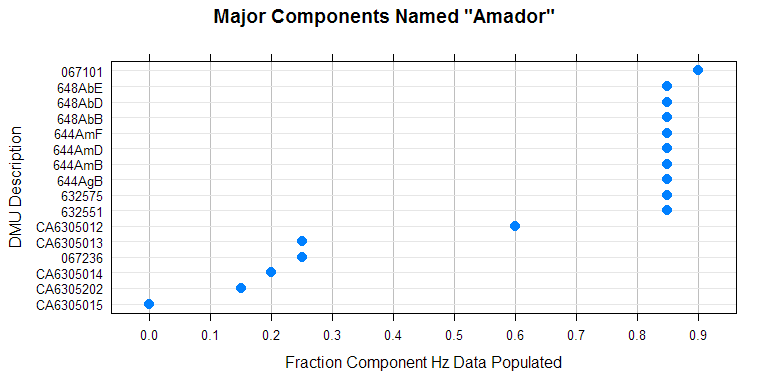

```r
# compute weighted fraction of hz data populated using component pct
p <- ddply(nc.combined, 'dmudesc', function(i) {
  with(i, sum((comppct_r / 100) * hz.data.present), na.rm=TRUE)
})
names(p) <- c('dmudesc', 'frac.populated')

# re-order musym labels in increasing order of hz data populated
p$dmudesc <- factor(p$dmudesc, levels=p$dmudesc[order(p$frac.populated)])

dotplot(dmudesc ~ frac.populated, data=p, cex=1.25, ylab='DMU Description', xlab='Fraction Component Hz Data Populated', main='Major Components Named "Amador"', scales=list(x=list(alternating=TRUE, tick.number=10)), subset=dmudesc != 'NOTCOM National DMU', panel=function(...){
  panel.abline(v=seq(0, 1, by=0.1), col='grey')
  panel.dotplot(...)
})
```

## Boring Details

Just kidding, this stuff matters.

### Status and QC Messages

As part of the quality control process, a number of possible messages are printed to the console when running `fetchNASIS_component_data()`. These messages and their meaning are described below:

- `-> QC: horizon errors detected ...` Horizon depths are checked for gaps, overlap, or bottom depths than are shallower than top depths. In most cases pedons flagged as having errors suggests a quality control issue. However, combination horizons (e.g. B/C) that have been entered as two distinct horizons sharing the same horizon depths will trigger this warning.
- `-> QC: DMUs assigned to multiple MU ...` This message means that some data map units in the selected set have been used within several different map units.
- `-> QC: duplicate muiids: multiple 'representative' DMU / MU ...` This message means that there may be several "representative" DMU assigned to a single map unit.

### Adjusting the Defaults

Some of the assumptions made by `fetchNASIS_component_data()` can be adjusted using arguments to the function:

- `rmHzErrors = TRUE` Setting this value to `TRUE` (the default) will enable checks for horizon depth consistency. Consider setting this argument to `FALSE` if you aren't concerned about horizon depth errors, or know that your selected set contains many combination horizons. Note that any records flagged as having horizon depths errors (`rmHzErrors = TRUE`) will be omitted from the data returned by `fetchNASIS_component_data()`.

An increased level of verbosity in the quality control messages can be enabled by setting the option: `options(soilDB.verbose=TRUE)`. This is not generally suggested, but may be useful if you are having difficulty loading data from NASIS.

This document is based on `aqp` version 1.9.5 and `soilDB` version 1.6.9.